# Pravdepodobnost a statistika

### Spojita rozdeleni

Normalni rozdeleni: Parametry: mu - stredni hodnota, sigma - smerodatna odchylka pnorm(x,mu,sigma) - distribucni funkce P(X <= x) qnorm(p,mu,sigma) - kvantilova funkce: x tak, ze P(X <= x) = p

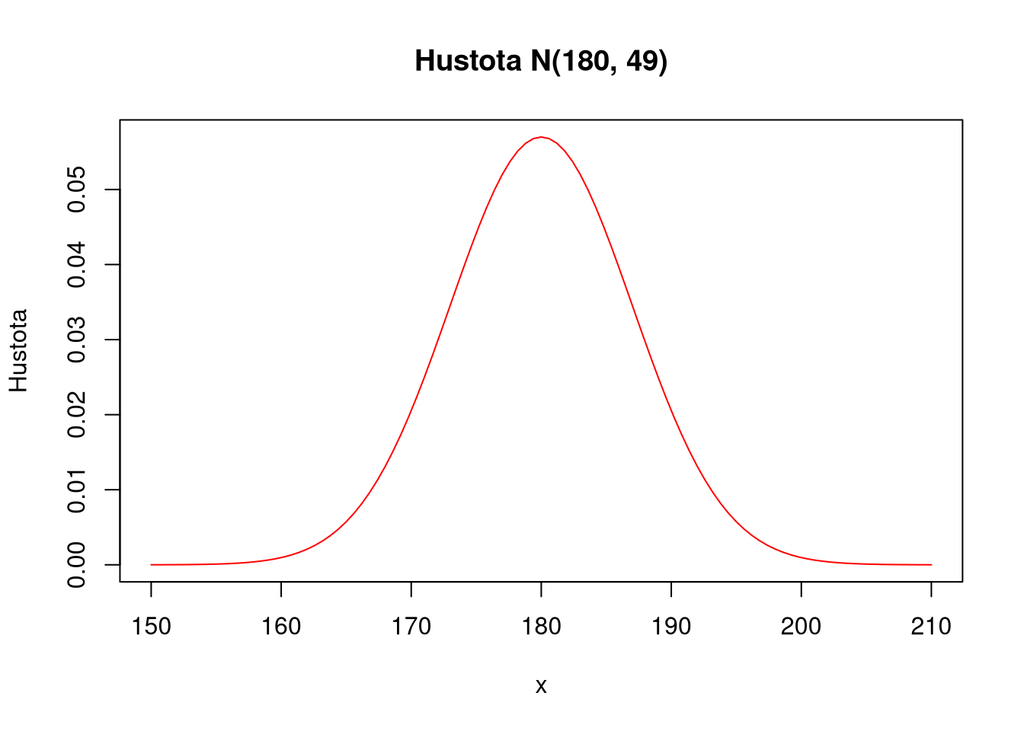

```r
# Grafy normalniho rozdeleni N(180, 49): vyska dospelych muzu

# hustota
curve(dnorm(x, 180, 7), from = 150, to = 210, main = "Hustota N(180, 49)", col = "red", ylab = "Hustota")
```

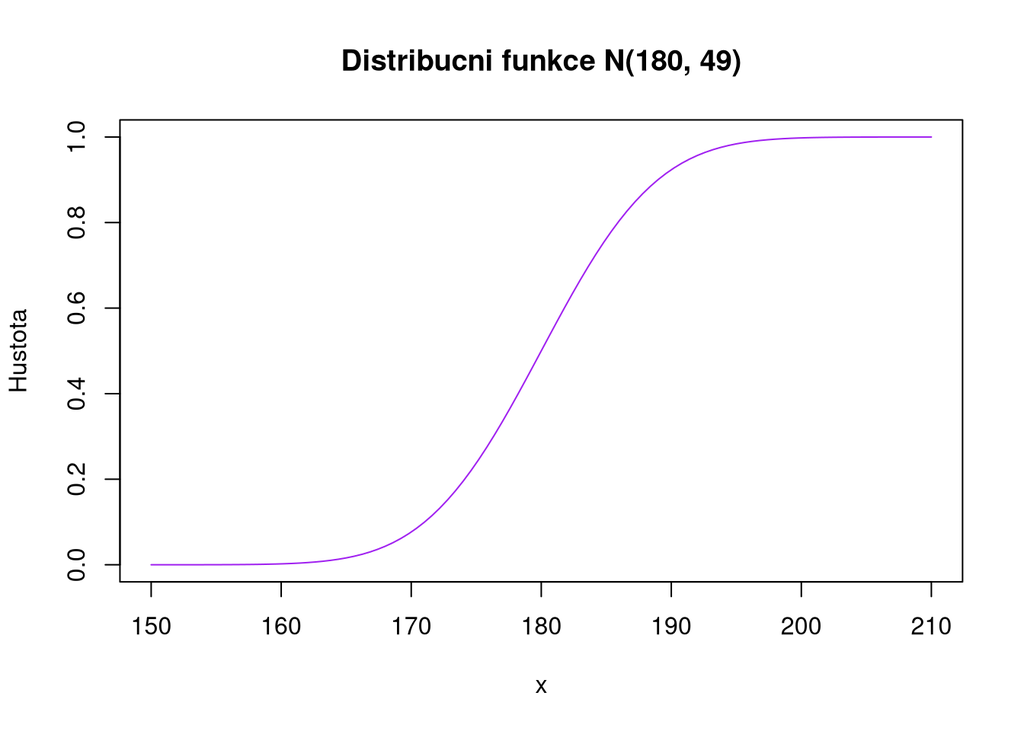

```r
# distribucni funkce
curve(pnorm(x, 180, 7), from = 150, to = 210, main = "Distribucni funkce N(180, 49)", col = "purple", ylab = "Hustota")
```

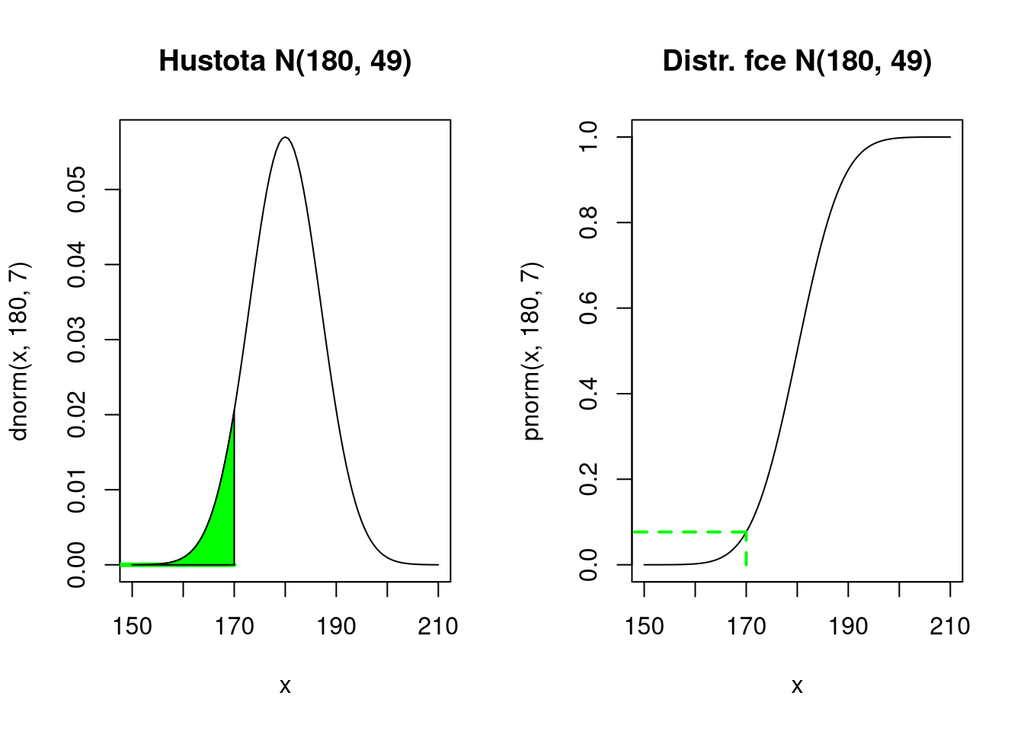

```r
# pravdepodobnost, ze nahodne vybrany muz bude mensi nez 170 cm
par(mfrow = c(1,2))
curve(dnorm(x, 180, 7), from = 150, to = 210, main = "Hustota N(180, 49)")
lines(c(0, 170), c(0, 0), lwd = 3, col = "green")
xx <- seq(150, 170, length.out = 101)
polygon(c(150, xx, 170), c(0, dnorm(xx, 180, 7), 0), col = "green")
  # umime-li zmerit velikost zelene plochy, mame pst :)

curve(pnorm(x, 180, 7), from = 150, to = 210, main = "Distr. fce N(180, 49)")
lines(c(170, 170), c(0, pnorm(170, 180, 7)), col = "green", lty = 2, lwd = 2)
lines(c(0, 170), c(pnorm(170, 180, 7), pnorm(170, 180, 7)), col = "green", lty = 2, lwd = 2)
```

```r
  # hodnotu lze vycist z distribucni funkce
par(mfrow = c(1, 1))
```

Exponencialni rozdeleni: doba cekani do udalosti Pramater: int - intenzita pexp(x,int) - distribucni funkce qexp(q,int) - kvantilova funkce distribucni funkce P(X <= t) = 1 - exp(-int*t) stredni hodnota 1/int rozptyl 1/int^2

### Vypocty pravdepodobnosti

P(X = k) = 0 pro libovolne k!!! P(X <= k) = P(X < k) … distribucni funkce v bode k P(X >= k) = P(X > k) = 1 - P(X <= k) … jedna minus distribucni funkce v bode k P(k <= X <= l) = P(X <= k) - P(X <= l) … rozdil distribucnich funkci v bodech k a l

Priklad 1

```r
# Hmotnost bochniku chleba ma normalni rozdeleni se stredni hodnotou 1.2 kg a smerodatnou odchylkou 30 g. Jaka je pravdepodobnost, ze bochnik, ktery si prinesu domu bude mi maximalne o 50 g mene, nez je optimalni vaha.
```

Priklad 2

```r
# Nahodna velicina X ma normalni rozdeleni N(2,5). Stanovte kvartily teto veliciny a jeji mezikvartilove rozpeti.
```

Priklad 3

```r
# Pojistovna si eviduje vsechny skody, ktere musela proplacet. Zjistila, ze vyska skody sa ridi logaritmicko-normalnim rozdelenim s parametry mu = 6 a sigma-kvadrat = 2. Urcete median vysky skody.
```

Priklad 4

```r
# V promitaci mistnosti bezi stale dokola smycka 20-minutoveho filmu. Urcite pravdepodobnost, ze kdyz nahodne vejdeme do mistnosti,  nebudeme na zacatek filmu cekat vic nez 5 minut.
```

Priklad 5

```r
# Cas neprimeho bunecneho deleni (tzv. mitoza) ma normalni rozdeleni se stredni hodnotou jedna hodina a rozptylem 25. Jaka je  pravdepodobnost, ze deleni nejake bunky se uskutecni nez za za 45 minut?
```

Priklad 6

```r
# Doba zivotnosti vyrobku ma exponencialni rozdeleni se stredni hodnotou 2000 dni. Urcete pravdepodobnost, ze vyrobok bude funkcni aspon 3000 dni.
```

Priklad 7

```r
# Rychlost prenosu souboru v kb za sekundu z ma lognormalni rozdeleni LN(3.75,0.50). Urcete pravdepodobnost, ze soubor bude prenasen rychlosti 70 kb za sekundu nebo vetsi.
```

Pomoci jednovyberoveho t-testu (prikaz t.test(promenne, mu = testovane cislo, alternative = “pozadovana alternativa”), kde pozadovana alternativa muze byt “less”, “greater”, “both.sided” - prednastavena verze, nemusi se zadavat) rozhodnete, zda stredni hodnota promenne hp v souboru mtcars muze byt 150?

```r
data(mtcars)
hp <- mtcars$hp
```